# Data Visualization I

## Loess smoothed scatterplot with points of various sizes

- Highway miles per gallon on displacement
- Color points by car class
- Point size by city miles per gallon (cty)
- Large red loess line for all point and no confidence interval

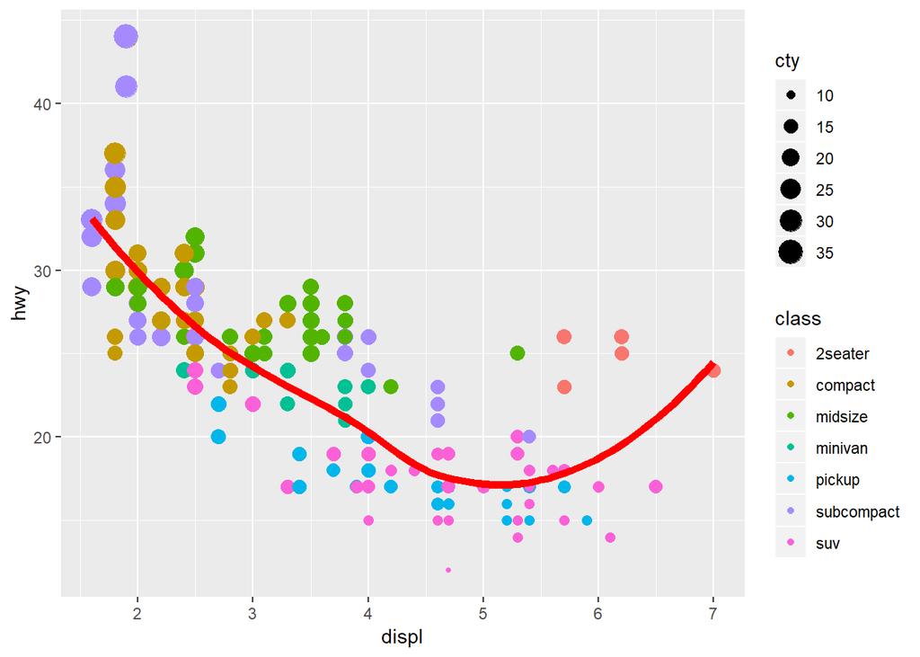

```r
ggplot(data = mpg, mapping = aes(x = displ, y = hwy)) +
  geom_point(mapping = aes(color = class, size = cty)) +
  geom_smooth(se = FALSE, size = 2, color = "red")
```

## Linear regression of highway on displacement

- Color by vehicle class
- Simple regression by vehicle class
- Show all points

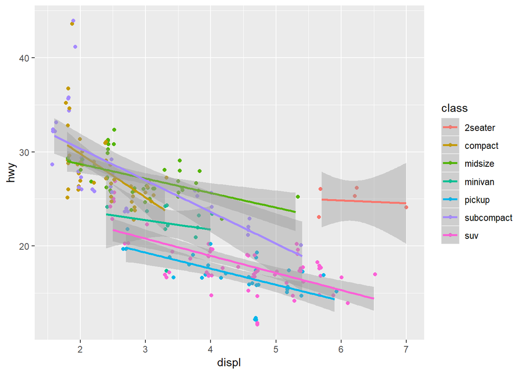

```r
ggplot(data = mpg, mapping = aes(x = displ, y = hwy, color = class)) +
  geom_point(position = "jitter") +
  geom_smooth(method = "lm")
```

## Linear regression of highway on displacement

- Color by vehicle class
- Simple regression by vehicle class
- Each class has its own scatterplot
- Show all the points
- No Legend

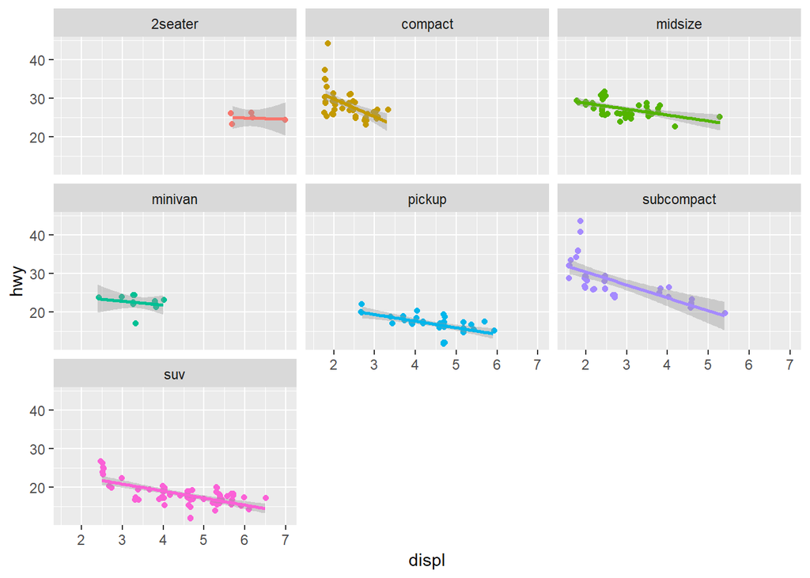

```r
ggplot(data = mpg, mapping = aes(x = displ, y = hwy, color = class)) +
  geom_point(position = "jitter", show.legend = FALSE) +
  geom_smooth(method = "lm", show.legend = FALSE) +
  facet_wrap(vars(class))
```

## Linear regression of highway on displacement

- Color by drivetrain type
- Simple regression by drive train type and number of cylinders
- Draw a larger, black regression line
- Each drive train and number of cylinders has its own scatterplot
- Show all the points
- No Legend

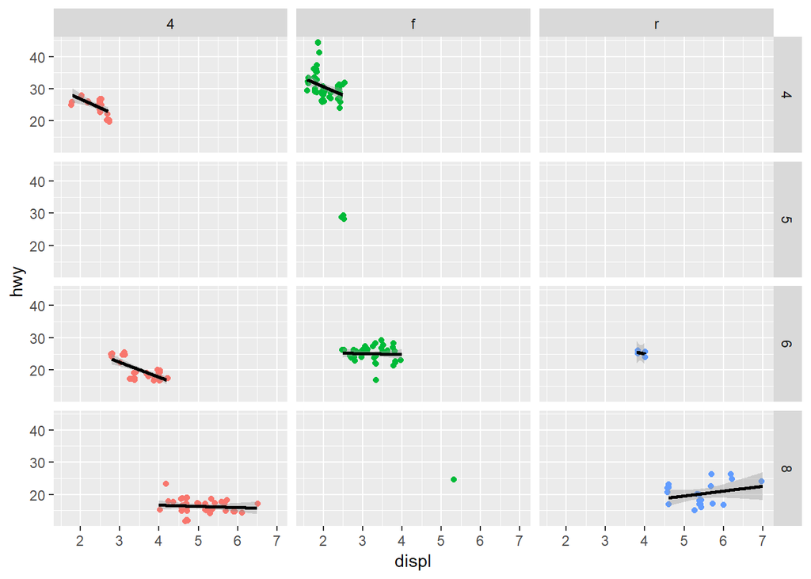

```r
ggplot(data = mpg, mapping = aes(x = displ, y = hwy, color = drv)) +
  geom_point(position = "jitter", show.legend = FALSE) +
  geom_smooth(method = "lm", show.legend = FALSE, color = "black", size = 1) +
  facet_grid(rows = vars(as.factor(cyl)), cols = vars(drv))
```

## Bar chart of car classes

- Bar colored by car class
- No legend

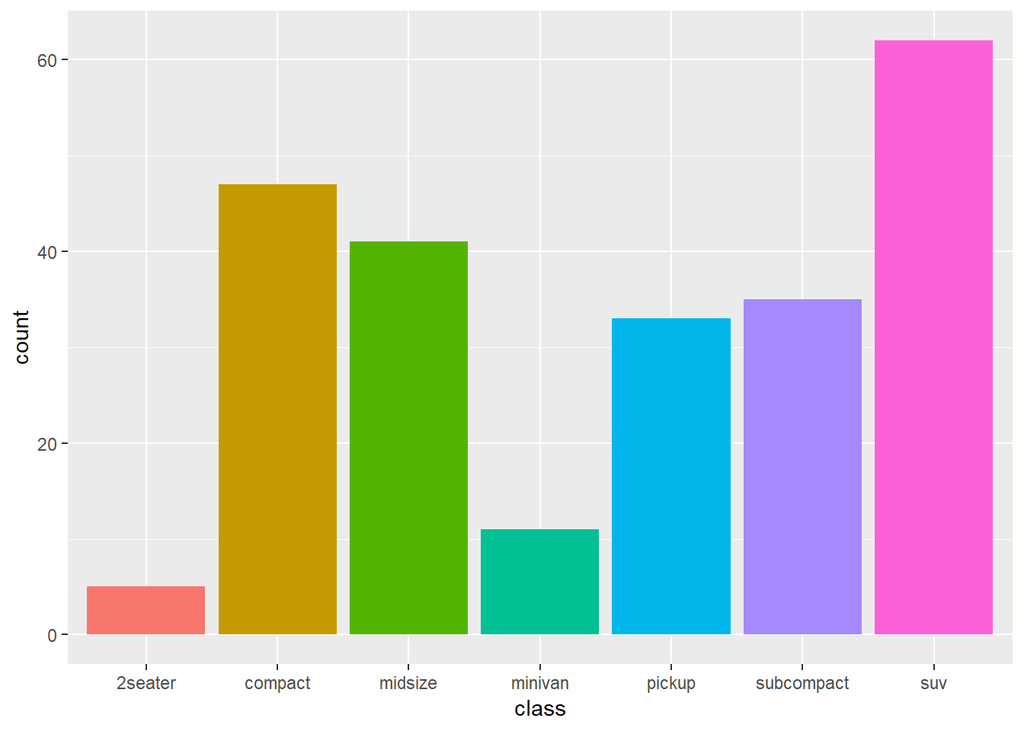

```r
ggplot(data = mpg, mapping = aes(x = class, fill = class)) +
  geom_bar(show.legend = FALSE)
```

## Bar chart of car classes

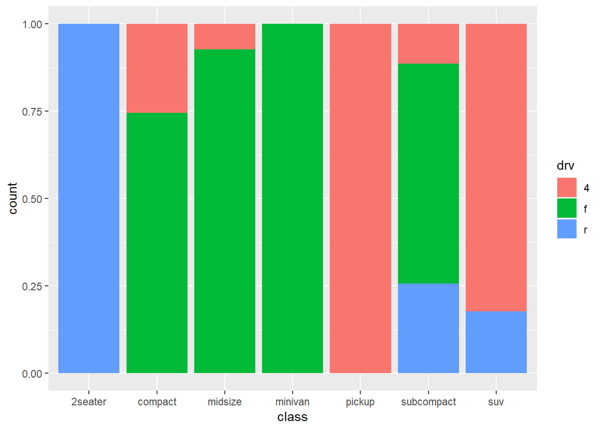

```r
ggplot(data = mpg, mapping = aes(x = class, fill = drv)) +
  geom_bar(position = "fill")
```

## Bar chart of car classes

- Vertical orientation
- Number of by drive train type for each vehicle class

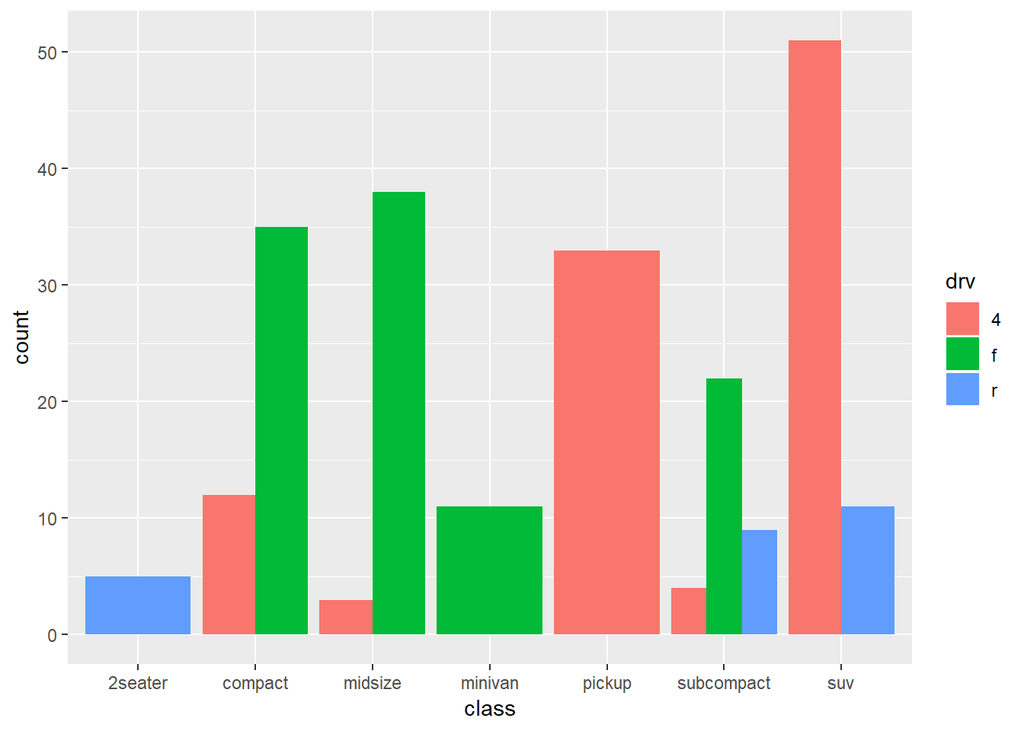

```r
ggplot(data = mpg, mapping = aes(x = class, fill = drv)) +
  geom_bar(position = "dodge")
```